# House Price Prediction

## Context

- This dataset contains house sale prices for King County, which includes Seattle. It includes homes sold between May 2014 and May 2015.
- For the sake of simplicity, it may be better to perform the analysis as if it were the year that these houses were sold. This will remove the possible need to adjust the age of the houses for the current year (2024) and possibly even the need to adjust prices for inflation - assuming that meaningful insights were the goal.  
  The data is the selling price of the homes in 2014/15 and this is more reflective of that current market price opposed to the homes underlying value. There are many other market factors that can effect this and will also need to be taken into consideration should a dataset this old be used for present day inferences. I think simplicity should prevail here.

**Dataset:**  
[House Sales in King County, USA (Kaggle)](https://www.kaggle.com/datasets/harlfoxem/housesalesprediction/discussion?sort=undefined)  
*note: In this project I am using a smaller version of this dataset with fewer features and instances.*

**Column Definitions:**  
id - Unique ID for each home sold  
date - Date of the home sale  
price - Price of each home sold  
bedrooms - Number of bedrooms  
bathrooms - Number of bathrooms, where .5 accounts for a room with a toilet but no shower  
sqft_living - Square footage of the apartments interior living space  
sqft_lot - Square footage of the land space  
floors - Number of floors (0.5 = split-level or bi-level floors)  
waterfront - A dummy variable for whether the apartment was overlooking the waterfront or not  
view - An index from 0 to 4 of how good the view of the property was  
condition - An index from 1 to 5 on the condition of the apartment  
grade - An index from 1 to 13, where 1-3 falls short of building construction and design, 7 has an average level of construction and design, and 11-13 have a high quality level of construction and design.  
sqft_above - The square footage of the interior housing space that is above ground level  
sqft_basement - The square footage of the interior housing space that is below ground level  
yr_built - The year the house was initially built  
yr_renovated - The year of the house’s last renovation  
zipcode - What zipcode area the house is in  
lat - Lattitude  
long - Longitude  
sqft_living15 - The square footage of interior housing living space for the nearest 15 neighbors  
sqft_lot15 - The square footage of the land lots of the nearest 15 neighbors

verified from 2 sources:  
https://www.slideshare.net/PawanShivhare1/predicting-king-county-house-prices  
https://rstudio-pubs-static.s3.amazonaws.com/155304_cc51f448116744069664b35e7762999f.html

## Set up

```python
import warnings
import numpy as np
import pandas as pd
from pandas.plotting import scatter_matrix
import matplotlib.pyplot as plt
import seaborn as sns

from sklearn.tree import DecisionTreeRegressor
from xgboost import XGBRegressor
from sklearn.ensemble import RandomForestClassifier
from sklearn.neighbors import KNeighborsClassifier

from sklearn.pipeline import Pipeline
from sklearn.compose import ColumnTransformer
from sklearn.preprocessing import StandardScaler, FunctionTransformer, label_binarize
from sklearn.base import BaseEstimator, TransformerMixin
from sklearn.utils.validation import check_array, check_is_fitted
from sklearn.feature_selection import SelectKBest, f_regression, f_classif

from sklearn.model_selection import train_test_split, cross_val_score, GridSearchCV
from sklearn.metrics import mean_squared_error, root_mean_squared_error, mean_absolute_error, r2_score
from sklearn.metrics import accuracy_score, precision_score, recall_score, f1_score, roc_curve, auc
from sklearn.metrics import confusion_matrix, ConfusionMatrixDisplay


warnings.filterwarnings("ignore")
sns.set()
```

```python
data = pd.read_csv("../data/kc_house_data.csv")
data.head()
```

|  | price | bedrooms | bathrooms | sqft_living | sqft_lot | floors | grade | sqft_above | sqft_basement | yr_built | yr_renovated | lat | long | sqft_living15 | sqft_lot15 | condition |
| --- | --- | --- | --- | --- | --- | --- | --- | --- | --- | --- | --- | --- | --- | --- | --- | --- |
| 0 | 221900.0 | 3 | 1.00 | 1180 | 5650 | 1.0 | 7 | 1180 | 0 | 1955 | 0 | 47.5112 | -122.257 | 1340 | 5650 | 3 |
| 1 | 538000.0 | 3 | 2.25 | 2570 | 7242 | 2.0 | 7 | 2170 | 400 | 1951 | 1991 | 47.7210 | -122.319 | 1690 | 7639 | 3 |
| 2 | 180000.0 | 2 | 1.00 | 770 | 10000 | 1.0 | 6 | 770 | 0 | 1933 | 0 | 47.7379 | -122.233 | 2720 | 8062 | 3 |
| 3 | 604000.0 | 4 | 3.00 | 1960 | 5000 | 1.0 | 7 | 1050 | 910 | 1965 | 0 | 47.5208 | -122.393 | 1360 | 5000 | 5 |
| 4 | 510000.0 | 3 | 2.00 | 1680 | 8080 | 1.0 | 8 | 1680 | 0 | 1987 | 0 | 47.6168 | -122.045 | 1800 | 7503 | 3 |

```python
# Investigating the data's structure
data.info()
```

```
<class 'pandas.core.frame.DataFrame'>
RangeIndex: 21613 entries, 0 to 21612
Data columns (total 16 columns):
 #   Column         Non-Null Count  Dtype
---  ------         --------------  -----
 0   price          21613 non-null  float64
 1   bedrooms       21613 non-null  int64
 2   bathrooms      21613 non-null  float64
 3   sqft_living    21613 non-null  int64
 4   sqft_lot       21613 non-null  int64
 5   floors         21613 non-null  float64
 6   grade          21613 non-null  int64
 7   sqft_above     21613 non-null  int64
 8   sqft_basement  21613 non-null  int64
 9   yr_built       21613 non-null  int64
 10  yr_renovated   21613 non-null  int64
 11  lat            21613 non-null  float64
 12  long           21613 non-null  float64
 13  sqft_living15  21613 non-null  int64
 14  sqft_lot15     21613 non-null  int64
 15  condition      21613 non-null  int64
dtypes: float64(5), int64(11)
memory usage: 2.6 MB
```

```python
# Investigating simple summary statistics
data.describe()
```

|  | price | bedrooms | bathrooms | sqft_living | sqft_lot | floors | grade | sqft_above | sqft_basement | yr_built | yr_renovated | lat | long | sqft_living15 | sqft_lot15 | condition |
| --- | --- | --- | --- | --- | --- | --- | --- | --- | --- | --- | --- | --- | --- | --- | --- | --- |
| count | 2.161300e+04 | 21613.000000 | 21613.000000 | 21613.000000 | 2.161300e+04 | 21613.000000 | 21613.000000 | 21613.000000 | 21613.000000 | 21613.000000 | 21613.000000 | 21613.000000 | 21613.000000 | 21613.000000 | 21613.000000 | 21613.000000 |
| mean | 5.401822e+05 | 3.370842 | 2.114757 | 2079.899736 | 1.510697e+04 | 1.494309 | 7.656873 | 1788.390691 | 291.509045 | 1971.005136 | 84.402258 | 47.560053 | -122.213896 | 1986.552492 | 12768.455652 | 3.409430 |
| std | 3.673622e+05 | 0.930062 | 0.770163 | 918.440897 | 4.142051e+04 | 0.539989 | 1.175459 | 828.090978 | 442.575043 | 29.373411 | 401.679240 | 0.138564 | 0.140828 | 685.391304 | 27304.179631 | 0.650743 |
| min | 7.500000e+04 | 0.000000 | 0.000000 | 290.000000 | 5.200000e+02 | 1.000000 | 1.000000 | 290.000000 | 0.000000 | 1900.000000 | 0.000000 | 47.155900 | -122.519000 | 399.000000 | 651.000000 | 1.000000 |
| 25% | 3.219500e+05 | 3.000000 | 1.750000 | 1427.000000 | 5.040000e+03 | 1.000000 | 7.000000 | 1190.000000 | 0.000000 | 1951.000000 | 0.000000 | 47.471000 | -122.328000 | 1490.000000 | 5100.000000 | 3.000000 |
| 50% | 4.500000e+05 | 3.000000 | 2.250000 | 1910.000000 | 7.618000e+03 | 1.500000 | 7.000000 | 1560.000000 | 0.000000 | 1975.000000 | 0.000000 | 47.571800 | -122.230000 | 1840.000000 | 7620.000000 | 3.000000 |
| 75% | 6.450000e+05 | 4.000000 | 2.500000 | 2550.000000 | 1.068800e+04 | 2.000000 | 8.000000 | 2210.000000 | 560.000000 | 1997.000000 | 0.000000 | 47.678000 | -122.125000 | 2360.000000 | 10083.000000 | 4.000000 |
| max | 7.700000e+06 | 33.000000 | 8.000000 | 13540.000000 | 1.651359e+06 | 3.500000 | 13.000000 | 9410.000000 | 4820.000000 | 2015.000000 | 2015.000000 | 47.777600 | -121.315000 | 6210.000000 | 871200.000000 | 5.000000 |

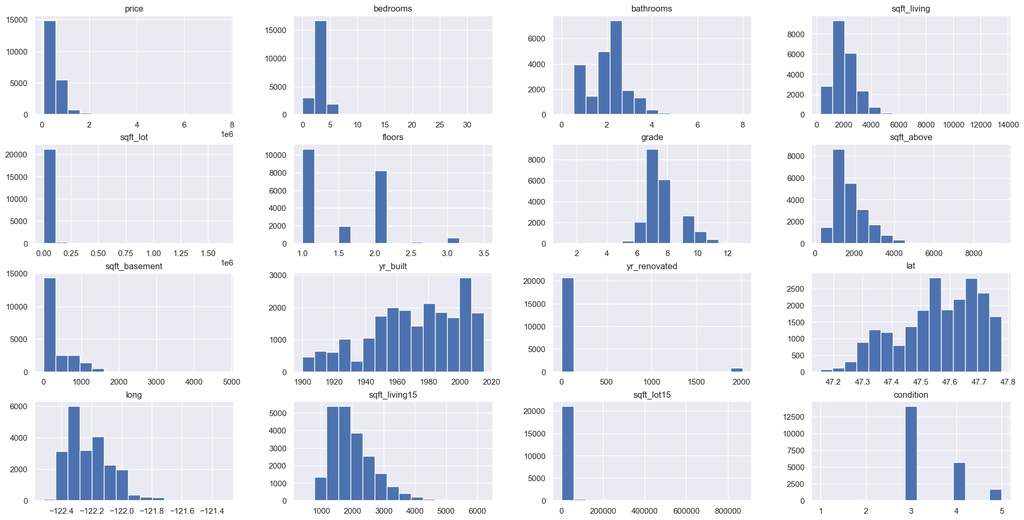

```python
# Quick look at the distribution of all features
data.hist(bins=15, figsize=(24,12));
```

```python
# Creating the train-test split before any further exploration to avoid any "data snooping" bias
X = data.iloc[:, 1:]
y = data.iloc[:, 0]
X_train, X_test, y_train, y_test = train_test_split(X, y, test_size=0.2, shuffle=True, random_state=42)

# A dataframe that contains both input and target features for ease of exploratory analysis
price_df = X_train.copy()
price_df[y_train.name] = y_train
```

## Exploratory Analysis

### General Exploration

For now, I will lead with curiosity and aim to develop a better sense of the data before looking for anything specific.

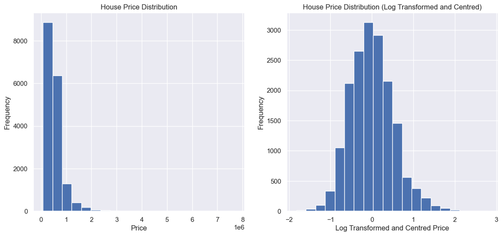

```python
# Due to how positively skewed house prices are, a log transformation of the target variable may lead to improved model performance
# Below I am simply investigating the log transformed (and 0 centred) distribution of the house prices
price_log = np.log(price_df['price'])
price_log_centered = price_log - np.mean(price_log)

# Side by side plots of the price distribution and the transformed distribution
fig, (ax1, ax2) = plt.subplots(1, 2, figsize=(14,6))
ax1.hist(price_df['price'], bins=20)
ax2.hist(price_log_centered, bins=20)

# Setting titles for each subplot
ax1.title.set_text("House Price Distribution")
ax2.title.set_text("House Price Distribution (Log Transformed and Centred)")

# Setting x and y labels for the first subplot
ax1.set_xlabel("Price")
ax1.set_ylabel("Frequency")

# Setting x and y labels for the second subplot
ax2.set_xlabel("Log Transformed and Centred Price")
ax2.set_ylabel("Frequency")

plt.show();
```

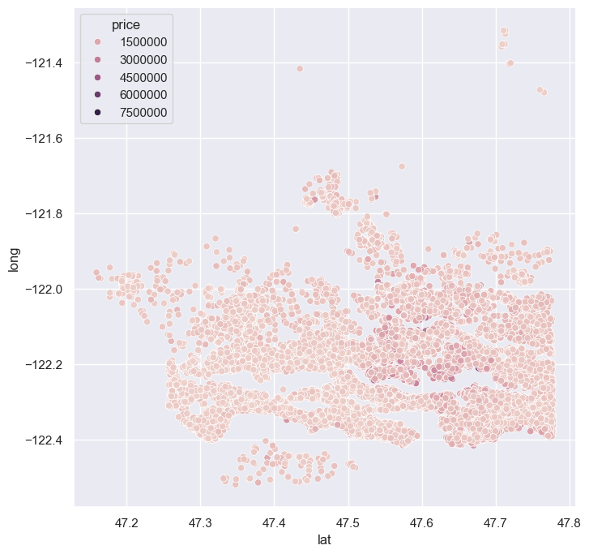

```python
# Heat map of house prices relative to their location
# The highest priced houses that were sold seem to be concentrated around a particular area, however this may not be a strong indication
# of any useful pattern that the model's can generalise to improve predictive power.

plt.figure(figsize=(8,8))
sns.scatterplot(data=price_df, x='lat', y='long', hue='price');
```

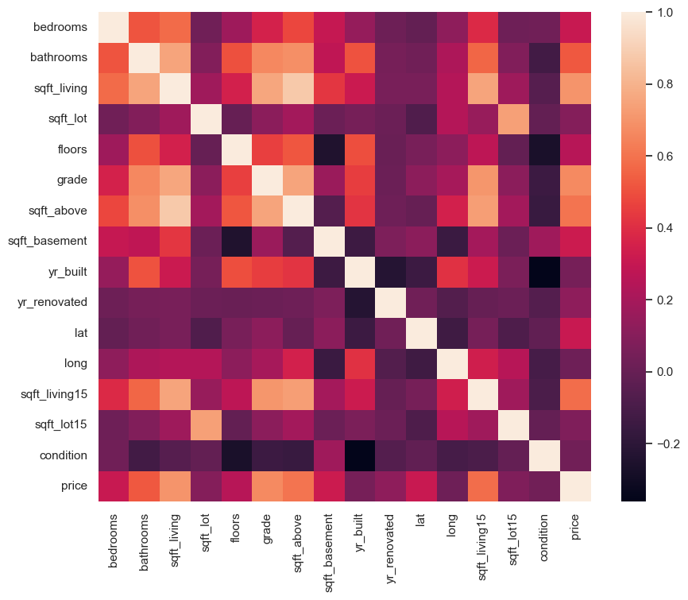

```python
# Quick look at potentially interesting linear relationships between all variables
# There appears to be a high correlation between many of the independent variables such as bedrooms and bathrooms or sqft_living and sqft_living15.
# This comes as no surprise but it may need to be considered when selecting features in order to improve model performance.
plt.figure(figsize=(10,8))
sns.heatmap(price_df.corr())

plt.show();
```

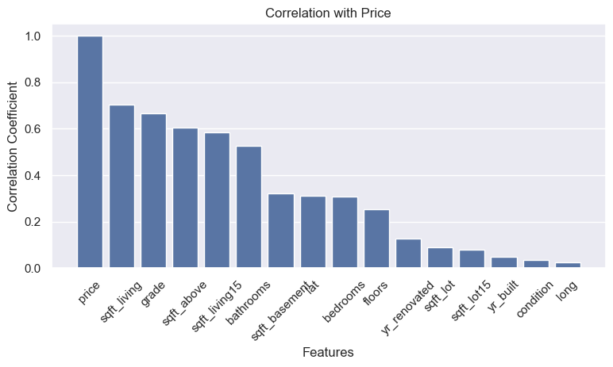

```python
# Ordered bar chart of Pearson correlation coefs of each feature and the house price
# The features that are more closely correlated to the price variable are sqft_living, grade, sqft_above, and sqft_living15.
# sqft_living and sqft_above are highly correlated with each other (as expected as sqft_above is a component of sqft_living)
# and may not be suitable for use together in the model.

corr_matrix = price_df.corr()[['price']].sort_values('price', ascending=False)

plt.subplots(figsize=(9,4))


sns.barplot(x=corr_matrix.index, y=corr_matrix['price'])
plt.title("Correlation with Price")
plt.xlabel("Features")
plt.ylabel("Correlation Coefficient")
plt.xticks(rotation=45)
plt.plot();
```

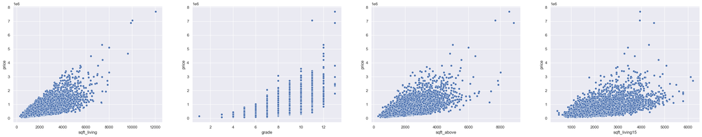

```python
# Scatter plots of sqft_living, grade, sqft_above, and sqft_living15
fig, axs = plt.subplots(1, 4, figsize=(35,6))
plot_features = price_df[['sqft_living', 'grade', 'sqft_above', 'sqft_living15']].columns


for i, col in enumerate(plot_features):
    sns.scatterplot(data=price_df, x=col, y='price', ax=axs[i])

plt.show()
```

## Preprocessing & Feature Engineering

There are no missing values in the dataset and all categorical features are already numeric. Additionally, all of the numeric categorical features are ordinal so it would not be appropriate to one-hot encode them as this ordinal structure (e.g three bedrooms is more than one two bedrooms and the house price will be correlated to this relationship) is important. Some categorical values will still need some adjusting and other variables will require a few minor changes such as floats being converted into integers and so on.  
My initial round of preprocessing was performed without using scikit-learn's pipeline framework. However, for the sake of reproduceability across all of the models in this project I have since refactored that code into functions and classes that are compatible with the pipeline framework. Initially, this was very challenging as I ran into many bugs but it has been a worthwhile endeavour as it has streamlined the project structure and greatly improved my skills.

```python
# Remove all outliers that fall outside of the specified threshold.
# threshold=3 will remove all values that are more than 3 standard deviations from the mean
class OutlierRemover(BaseEstimator, TransformerMixin):
    def __init__(self, threshold=3):
        self.threshold = threshold

    def fit(self, X, y=None):
        self.mean_ = np.mean(X, axis=0)
        self.std_ = np.std(X, axis=0)
        return self

    def transform(self, X, y=None):
        mask = np.abs((X - self.mean_) / self.std_) < self.threshold
        valid_rows = mask.all(axis=1)  # A series that evaluates to True for rows where all values are below threshold
        X_clean = X[valid_rows]
        y_clean = y[valid_rows]
        return (X_clean, y_clean)

    def fit_transform(self, X, y=None):
        self.fit(X)
        return self.transform(X, y)
```

```python
# All values for bathrooms will be rounded down as decimal values represent rooms with a toilet but no shower.
def round_down_int(X):
    '''Round all floats down before converting values into integer type (will be used solely for the 'bathroom' feature)'''
    return np.floor(X).astype(int)

round_down_transformer = FunctionTransformer(func=round_down_int)



# As homes with .5 floors are defined as split-level or bi-level floors they will be rounded up for simplicity
def round_nearest(X):
    '''Round all floats to nearest integer before converting values into integer type (will be used solely for the 'floors' feature)'''
    return np.round(X).astype(int)

round_transformer = FunctionTransformer(func=round_nearest)



# yr_built will be converted into 'age' (relative to the year of sale in 2015)
# I think it is more suitable to convert 'yr_built' into house age as the age will provide a clearer representation of a house's potential
# condition or depreciation. There is also no time series component to the analysis/model. Futhermore, scaling the year_built will
# likely lead to abstract values with little meaning.
def calculate_age(yr_built_column):
    '''Subtract all values from 2015 resulting in the age of the property at the time of sale (year 2015)'''
    return 2015 - yr_built_column

age_transformer = FunctionTransformer(func=calculate_age)



# 'yr_renovated' will be converted into binary variables stating whether the house has been renovated within a certain number of years
def renovated_within(yr_renovated_column):
    '''Calculate whether the property was renovated within the last 20, 10, and 5 years.'''

    # Calculate binary flags for different renovation periods
    renovated_20 = np.where(yr_renovated_column > 0, (2015 - yr_renovated_column) <= 20, False).astype(int)
    renovated_10 = np.where(yr_renovated_column > 0, (2015 - yr_renovated_column) <= 10, False).astype(int)
    renovated_5 = np.where(yr_renovated_column > 0, (2015 - yr_renovated_column) <= 5, False).astype(int)

    # Stack the arrays column-wise
    return np.column_stack((renovated_20, renovated_10, renovated_5))

yr_renovated_transformer = FunctionTransformer(func=renovated_within)
```

```python
# Initially this custom transformer was built to be used within the below pipeline
# As scikit-learn's pipeline expects transformations to be applied to feature inputs only, I have struggled to build a custom transformer that will
# remove rows (where outliers are present) from both the input features and the target variable (to ensure their lengths are equal when piped
# into the predictor). For this reason, I have removed outliers before implementing the pipeline.
# This unfortunately means that I cannot use GridSearchCV to evaluate different thresholds for outlier removal.
# However, this remains an opportunity for growth and possible model improvement in further iterations.

# Removing outliers with a custom transformer
outlier_remover = OutlierRemover(threshold=3)
X_train_clean, y_train_clean = outlier_remover.fit_transform(X_train, y_train)
```

```python
# Preprocessing pipelines
age_pipeline = Pipeline([
    ('compute_age', age_transformer),
    ('scale', StandardScaler())
])


# Full preprocessing pipeline using ColumnTransformer to apply transformations seperately to relevant features
cont_features = ['sqft_living', 'sqft_lot', 'sqft_above', 'sqft_basement',
                 'lat', 'long', 'sqft_living15', 'sqft_lot15']

full_preprocessing = ColumnTransformer([
    ('round_bathrooms', round_down_transformer, ['bathrooms']),
    ('round_floors', round_transformer, ['floors']),
    ('transform_age', age_pipeline, ['yr_built']),
    ('yr_renovated_binaries', yr_renovated_transformer, ['yr_renovated']),
    ('scale_cont', StandardScaler(), cont_features)
],
    remainder='passthrough')
```

# Regression - Decision Tree & XGBoost

## Decision Tree Regression

```python
# Decision tree regressor
full_pipeline_dt = Pipeline([
    ('preprocessing', full_preprocessing),
    ('feature_selection', SelectKBest(score_func=f_regression)),
    ('decision_tree', DecisionTreeRegressor(random_state=42))
])


# Hyperparameters to be used in the search
# These are somewhat conservative values as the computational demand increased drastically with a full range
# of possible hyperparameters to search through. It is very likely that a better model could be found provided
# I have more compute.
all_features = X_train_clean.shape[1]
param_grid_dt = {
    'feature_selection__k': [1, 4, 8, 12, all_features],
    'decision_tree__max_depth': [10, 15, None],
    'decision_tree__min_samples_split': [2, 5, 20],
    'decision_tree__min_samples_leaf': [5, 10],
    'decision_tree__max_features': [10, 15],
    'decision_tree__max_leaf_nodes': [None, 20, 50]
}

# Implementing grid search CV
grid_search_dt = GridSearchCV(
    full_pipeline_dt,
    param_grid_dt,
    error_score='raise', #Just incase as I have had a lot of issues with debugging
    cv=5,
    scoring='r2',
    n_jobs=-1,
    verbose=3
)

# Fit and output the best hyperparameters with corresponding best score
grid_search_dt.fit(X_train_clean, y_train_clean)
print(f"Best hyperparameters = {grid_search_dt.best_params_}")
print(f"Best score = {grid_search_dt.best_score_}")
```

```
Fitting 5 folds for each of 540 candidates, totalling 2700 fits
Best hyperparameters = {'decision_tree__max_depth': 15, 'decision_tree__max_features': 15, 'decision_tree__max_leaf_nodes': None, 'decision_tree__min_samples_leaf': 10, 'decision_tree__min_samples_split': 2, 'feature_selection__k': 15}
Best score = 0.7739304897327594
```

### Analysis of Cross-Validation Scores

```python
# Computing cross-validation scores using the best estimator
# Using more cv folds for greater reliability/accuracy as there is only one model being validated, unlike when searching for the best
# hyperparameters with GridSearchCV. (So I don't have to worry about my CPU melting)
cv_scores = cross_val_score(
    grid_search_dt.best_estimator_,
    X_train_clean,
    y_train_clean,
    cv=20,
    scoring='r2'
)

# Cross-validation descriptive statistics
mean_cv_score = np.mean(cv_scores)
std_cv_score = np.std(cv_scores)
min_cv_score = np.min(cv_scores)
max_cv_score = np.max(cv_scores)

# Fit the model on the entire training set and compute training score
best_model = grid_search_dt.best_estimator_
best_model.fit(X_train_clean, y_train_clean)
train_score = r2_score(y_train_clean, best_model.predict(X_train_clean))

print(f"Cross-validation Mean Score: {mean_cv_score:.3f}")
print(f"Cross-validation Standard Deviation: {std_cv_score:.3f}")
print(f"Cross-validation Min Score: {min_cv_score:.3f}")
print(f"Cross-validation Max Score: {max_cv_score:.3f}")
print("")
print(f"Training Score: {train_score:.3f}")

if train_score > mean_cv_score:
    print(f"Training Score is higher than the Cross-validation Mean by {train_score - mean_cv_score:.2f}")
else:
    print(f"Training Score is lower than the Cross-validation Mean by {mean_cv_score - train_score:.2f}")
```

[output not shown]

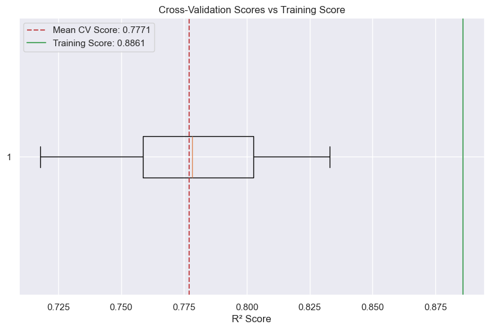

```python
# Boxplot for cross-validation scores
plt.figure(figsize=(10, 6))

plt.boxplot(cv_scores, vert=False)
plt.axvline(mean_cv_score, color='r', linestyle='--', label=f'Mean CV Score: {mean_cv_score:.4f}')
plt.axvline(train_score, color='g', linestyle='-', label=f'Training Score: {train_score:.4f}')

plt.xlabel('R² Score')
plt.title('Cross-Validation Scores vs Training Score')
plt.legend()

plt.show()
```

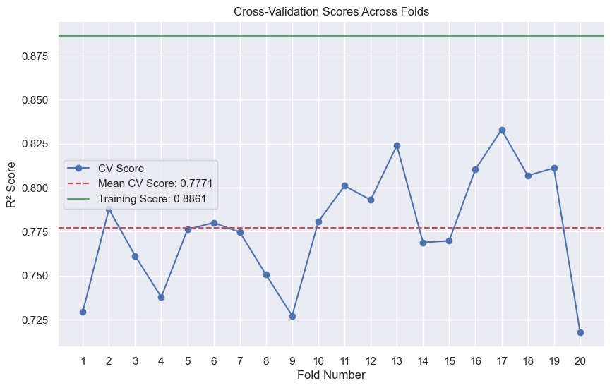

```python
# Line plot for cross-validation scores
folds = np.arange(1, len(cv_scores) + 1)
plt.figure(figsize=(10, 6))
plt.grid(True)

plt.plot(range(1, len(cv_scores) + 1), cv_scores, marker='o', linestyle='-', label='CV Score')
plt.axhline(mean_cv_score, color='r', linestyle='--', label=f'Mean CV Score: {mean_cv_score:.4f}')
plt.axhline(train_score, color='g', linestyle='-', label=f'Training Score: {train_score:.4f}')

plt.title('Cross-Validation Scores Across Folds')
plt.xlabel('Fold Number')
plt.ylabel('R² Score')

plt.xticks(folds)
plt.legend()

plt.show()
```

### Final Evaluation

```python
# Best model from grid search
best_model_dt = grid_search_dt.best_estimator_

# Predict on the test set
y_pred_dt = best_model_dt.predict(X_test)

# Calculate evaluation metrics
mse_dt = mean_squared_error(y_test, y_pred_dt)
rmse_dt = np.sqrt(mse_dt)
mae_dt = mean_absolute_error(y_test, y_pred_dt)
r2_dt = r2_score(y_test, y_pred_dt)

# Display metrics
print(f"Mean Squared Error (MSE): {mse_dt:.4f}")
print(f"Root Mean Squared Error (RMSE): {rmse_dt:.4f}")
print(f"Mean Absolute Error (MAE): {mae_dt:.4f}")
print(f"R-squared (R²): {r2_dt:.4f}")
```

```
Mean Squared Error (MSE): 42090897527.6323
Root Mean Squared Error (RMSE): 205160.6627
Mean Absolute Error (MAE): 97135.1529
R-squared (R²): 0.7219
```

### Notes:

- The cross-validation mean score (0.777) although not amazing indicates reasonably good predictive performance on unseen data and the standard deviation across folds (0.032) would suggest that the model is somewhat consistent and does not suffer from a great deal of variance. At the very least, judging by the box plots distribution the variance between validation scores are symmetrically distributed.
- The training score (0.886) is higher than the cross-validation mean score (0.777) by 0.11, suggesting a moderate degree of overfitting. This could be due to the model's complexity. For instance, the chosen grid search parameters for the minimum samples per leaf is 10 and the maximum depth is 15. This could lead to the model fitting to idiosyncratic patterns in the training data. If these were limited to lower values it could have a positive effect on the model's generalisation error.
- With that being said, the disparity between the test set performance (0.7219) and the cross-validation mean Score (0.777) is quite low. Considering that about 25% of the variability in house price has not been explained and the RMSE of the model is around \$205,000 I believe that it is far more likely that the model is simply not performing as well as it could and it is more likely that it is underfitting. In support of this theory, the MAE is around \\$97,000 which is half that of the RMSE and suggests the presence of some large errors. As I have removed all outliers (+ or - r standard deviations) from the training set, I believe many examples of very expensive homes have been lost. This could be leading to a drop in the model's performance and a large differenct between the MAE and RMSE.
- Possible improvements might entail including these outliers in the training set, restricting the complexity of the decision tree or simply implementing an ensemble of decently performing decision trees.

## XGBoost Regression

```python
# XGBoost pipeline
full_pipeline_xgb = Pipeline([
    ('preprocessing', full_preprocessing),
    ('feature_selection', SelectKBest(score_func=f_regression)),
    ('xgboost', XGBRegressor(objective='reg:squarederror', random_state=42))
])

# Hyperparameters to be used in the search for XGBoost
# These are somewhat conservative values as the computational demand increased drastically with a full range
# of possible hyperparameters to search through. It is very likely that a better model could be found provided
# I have more compute.
param_grid_xgb = {
    'feature_selection__k': [1, 4, 8, 12, all_features],
    'xgboost__max_depth': [5, 10],
    'xgboost__learning_rate': [0.05, 0.1],
    'xgboost__n_estimators': [50, 100],
    'xgboost__subsample': [0.8, 1.0],
    'xgboost__colsample_bytree': [0.8, 1.0]
}

# Implementing grid search CV for XGBoost
grid_search_xgb = GridSearchCV(
    full_pipeline_xgb,
    param_grid_xgb,
    error_score='raise',
    cv=5,
    scoring='r2',
    n_jobs=-1,
    verbose=3
)

# Fit and output the best hyperparameters with corresponding best score
grid_search_xgb.fit(X_train_clean, y_train_clean)
print(f"Best hyperparameters = {grid_search_xgb.best_params_}")
print(f"Best score = {grid_search_xgb.best_score_}")
```

```
Fitting 5 folds for each of 160 candidates, totalling 800 fits
Best hyperparameters = {'feature_selection__k': 15, 'xgboost__colsample_bytree': 0.8, 'xgboost__learning_rate': 0.05, 'xgboost__max_depth': 10, 'xgboost__n_estimators': 100, 'xgboost__subsample': 0.8}
Best score = 0.8526601735935888
```

### Analysis of Cross-Validation Scores

```python
# Computing cross-validation scores using the best estimator
cv_scores = cross_val_score(
    grid_search_xgb.best_estimator_,
    X_train_clean,
    y_train_clean,
    cv=20,
    scoring='r2'
)

# Cross-validation descriptive statistics
mean_cv_score = np.mean(cv_scores)
std_cv_score = np.std(cv_scores)
min_cv_score = np.min(cv_scores)
max_cv_score = np.max(cv_scores)

# Fit the model on the entire training set and compute training score
best_model = grid_search_xgb.best_estimator_
best_model.fit(X_train_clean, y_train_clean)
train_score = r2_score(y_train_clean, best_model.predict(X_train_clean))

print(f"Cross-validation Mean Score: {mean_cv_score:.3f}")
print(f"Cross-validation Standard Deviation: {std_cv_score:.3f}")
print(f"Cross-validation Min Score: {min_cv_score:.3f}")
print(f"Cross-validation Max Score: {max_cv_score:.3f}")
print("")
print(f"Training Score: {train_score:.3f}")

if train_score > mean_cv_score:
    print(f"Training Score is higher than the Cross-validation Mean by {train_score - mean_cv_score:.2f}")
else:
    print(f"Training Score is lower than the Cross-validation Mean by {mean_cv_score - train_score:.2f}")
```

[output not shown]

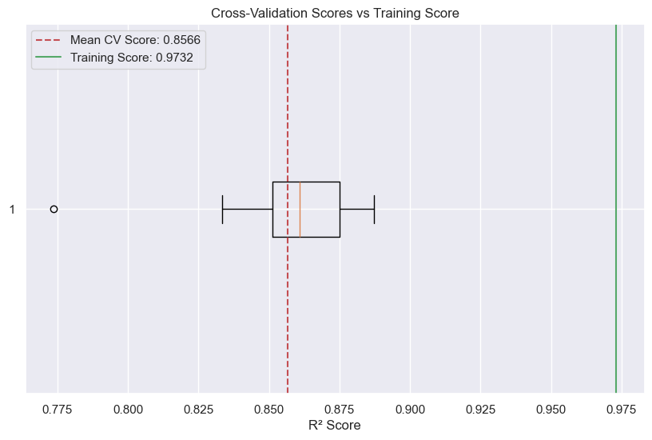

```python
# Boxplot for cross-validation scores
plt.figure(figsize=(10, 6))

plt.boxplot(cv_scores, vert=False)
plt.axvline(mean_cv_score, color='r', linestyle='--', label=f'Mean CV Score: {mean_cv_score:.4f}')
plt.axvline(train_score, color='g', linestyle='-', label=f'Training Score: {train_score:.4f}')

plt.xlabel('R² Score')
plt.title('Cross-Validation Scores vs Training Score')
plt.legend()

plt.show()
```

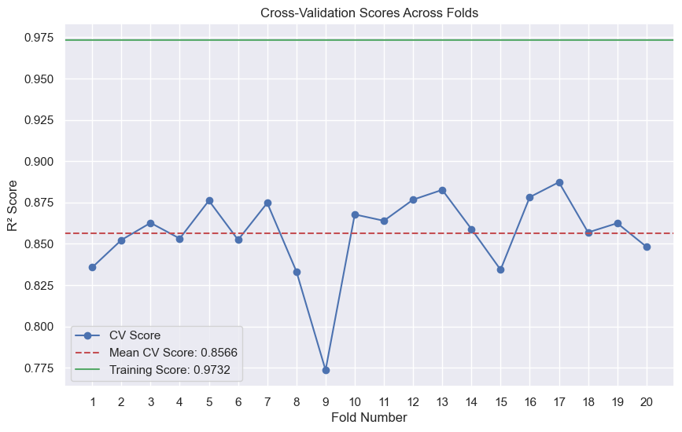

```python
# Line plot for cross-validation scores
folds = np.arange(1, len(cv_scores) + 1)
plt.figure(figsize=(10, 6))
plt.grid(True)

plt.plot(range(1, len(cv_scores) + 1), cv_scores, marker='o', linestyle='-', label='CV Score')
plt.axhline(mean_cv_score, color='r', linestyle='--', label=f'Mean CV Score: {mean_cv_score:.4f}')
plt.axhline(train_score, color='g', linestyle='-', label=f'Training Score: {train_score:.4f}')

plt.title('Cross-Validation Scores Across Folds')
plt.xlabel('Fold Number')
plt.ylabel('R² Score')

plt.xticks(folds)
plt.legend()

plt.show()
```

### Final Evaluation

```python
# Best model from grid search
best_model_xgb = grid_search_xgb.best_estimator_

# Predict on the test set
y_pred_xgb = best_model_xgb.predict(X_test)

# Calculate evaluation metrics
mse_xgb = mean_squared_error(y_test, y_pred_xgb)
rmse_xgb = np.sqrt(mse_xgb)
mae_xgb = mean_absolute_error(y_test, y_pred_xgb)
r2_xgb = r2_score(y_test, y_pred_xgb)

# Display metrics
print(f"Mean Squared Error (MSE): {mse_xgb:.4f}")
print(f"Root Mean Squared Error (RMSE): {rmse_xgb:.4f}")
print(f"Mean Absolute Error (MAE): {mae_xgb:.4f}")
print(f"R-squared (R²): {r2_xgb:.4f}")
```

```
Mean Squared Error (MSE): 34872972736.0413
Root Mean Squared Error (RMSE): 186743.0661
Mean Absolute Error (MAE): 79243.7717
R-squared (R²): 0.7696
```

### Notes:

- The cross-validation mean score (0.857) indicates that the model performs well on unseen data on average. This score represents a strong predictive capability.
- Conversely, the training score (0.973) is significantly higher than the cross-validation mean score (0.857). The gap of 0.12 suggests that the model may be overfitting the training data and learning patterns too specific to the training set while failing to generalise to new data. This is then confirmed with the large drop in performance when evaluated with the test set (0.7696).
- Cross-validation standard deviation: 0.024 is relatively small, indicating that the model's performance across different folds is consistent. A low standard deviation suggests that the model is stable and not overly sensitive to the specific partitioning of the data. However, the model performed quite poorly on the 9th fold. This could be suggestive of the presence of anomalous data in that particular validation fold. Additionally, the range of scores (max - min = 0.113) shows some variability in performance, but this is much lower when the 9th fold is accounted for.
- It is possible that improvements can be made by increasing the use of regularisation with this model or simply reducing the complexity of the model. For instance GridSearchCV found that the best model used all 15 features but considering that many of these features were highly correlated with each other I believe that more rigourous investigation and feature selection could lead to a better performing model.
- The most notable differences between the previous decision tree and this XGBoost algorithm is the ~10% increase in performance across the validation folds (measured by the mean score across validation folds) and the reduction of variability in validation scores. As expected with an ensemble of decision trees the XGBoost algorithm seems to have a greater degree of bias. Even though I believe this is a sign of a better model by comparison it is worth noting that this has only translated to an improvement of 7% or so in the test set and thus the model could still benefit from a greater degree of bias as stated above.

[figure not shown]

```python
folds = list(range(1, 21))
decision_tree_scores = [0.680, 0.621, 0.634, 0.644, 0.688, 0.573, 0.605, 0.664, 0.563, 0.657,
                        0.678, 0.667, 0.609, 0.602, 0.633, 0.632, 0.654, 0.688, 0.585, 0.643]
xgboost_scores = [0.761, 0.727, 0.720, 0.722, 0.751, 0.712, 0.733, 0.747, 0.727, 0.736,
                  0.730, 0.764, 0.701, 0.694, 0.717, 0.766, 0.757, 0.755, 0.703, 0.729]

# Plotting Cross-Validation Scores
plt.figure(figsize=(12, 6))
plt.plot(folds, decision_tree_scores, label="Decision Tree Regressor", marker='o')
plt.plot(folds, xgboost_scores, label="XGBoost Regressor", marker='s')
plt.axhline(y=sum(decision_tree_scores)/len(decision_tree_scores), color='blue', linestyle='--', label='Decision Tree Mean')
plt.axhline(y=sum(xgboost_scores)/len(xgboost_scores), color='orange', linestyle='--', label='XGBoost Mean')
plt.title("Cross-Validation Scores Across Folds")
plt.xlabel("Fold Number")
plt.ylabel("Score")
plt.legend()
plt.grid(True)
plt.show()
```

# Classification - Random Forest & KNN

## Preprocessing

```python
# Creating the dataframe that will be used for classification
# Add feature that categorises price into two bins: low (0) and high (1) using the median as the threshold
data_clf = data.copy()
data_clf['price_high'] = np.where(data_clf['price'] <= data_clf['price'].median(), 0, 1)
data_clf = data_clf.drop('price', axis=1)
```

```python
# Creating the train-test split
X_clf = data_clf.iloc[:, :-1]
y_clf = data_clf.iloc[:, -1]
X_train, X_test, y_train, y_test = train_test_split(X_clf, y_clf, test_size=0.2, shuffle=True, random_state=42)
```

```python
# Removing outliers with a custom transformer
outlier_remover = OutlierRemover(threshold=3)
X_train_clean, y_train_clean = outlier_remover.fit_transform(X_train, y_train)
```

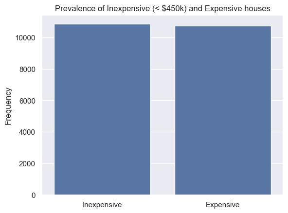

```python
# Bar chart showing the prevalence of expensive house compared to inexpensive houses
# (Based on the definition of an expensive house being one that is above the median of the data set)
sns.barplot(x=['Inexpensive', 'Expensive'], y=data_clf['price_high'].value_counts())

plt.title(f"Prevalence of Inexpensive (< ${data['price'].median()/1000:.0f}k) and Expensive houses")
plt.ylabel("Frequency")

plt.show()
```

## Random Forest Classification

```python
# Random Forest Classifier
full_pipeline_rf = Pipeline([
    ('preprocessing', full_preprocessing),
    ('feature_selection', SelectKBest(score_func=f_classif)),
    ('random_forest', RandomForestClassifier(random_state=42))
])

# Hyperparameters to be used in the search
# These are somewhat conservative values as the computational demand increased drastically with a full range
# of possible hyperparameters to search through. It is very likely that a better model could be found provided
# I have more compute.
param_grid_rf = {
    'feature_selection__k': [1, 4, 8, 12, all_features],
    'random_forest__n_estimators': [50, 100],
    'random_forest__max_depth': [10, 20, None],
    'random_forest__min_samples_split': [2, 5],
    'random_forest__min_samples_leaf': [1, 2],
    'random_forest__max_features': ['sqrt', 'log2'],
    'random_forest__bootstrap': [True]
}

# Implementing grid search CV
grid_search_rf = GridSearchCV(
    full_pipeline_rf,
    param_grid_rf,
    error_score='raise',
    cv=5,
    scoring='accuracy',
    n_jobs=-1,
    verbose=3
)

# Fit and output the best hyperparameters with corresponding best score
grid_search_rf.fit(X_train_clean, y_train_clean)
print(f"Best hyperparameters = {grid_search_rf.best_params_}")
print(f"Best score = {grid_search_rf.best_score_}")
```

```
Fitting 5 folds for each of 240 candidates, totalling 1200 fits
Best hyperparameters = {'feature_selection__k': 15, 'random_forest__bootstrap': True, 'random_forest__max_depth': 20, 'random_forest__max_features': 'sqrt', 'random_forest__min_samples_leaf': 2, 'random_forest__min_samples_split': 5, 'random_forest__n_estimators': 100}
Best score = 0.9067464361163877
```

### Analysis of Cross-Validation Scores

```python
# Computing cross-validation scores using the best estimator
# Using more cv folds for greater reliability/accuracy as there is only one model being validated, unlike when searching for the best
# hyperparameters with GridSearchCV. (So I don't have to worry about my CPU melting)
cv_scores = cross_val_score(
    grid_search_rf.best_estimator_,
    X_train_clean,
    y_train_clean,
    cv=20,
    scoring='accuracy'
)

# Cross-validation descriptive statistics
mean_cv_score = np.mean(cv_scores)
std_cv_score = np.std(cv_scores)
min_cv_score = np.min(cv_scores)
max_cv_score = np.max(cv_scores)

# Fit the model on the entire training set and compute training score
best_model = grid_search_rf.best_estimator_
best_model.fit(X_train_clean, y_train_clean)
train_score = r2_score(y_train_clean, best_model.predict(X_train_clean))

print(f"Cross-validation Mean Score: {mean_cv_score:.3f}")
print(f"Cross-validation Standard Deviation: {std_cv_score:.3f}")
print(f"Cross-validation Min Score: {min_cv_score:.3f}")
print(f"Cross-validation Max Score: {max_cv_score:.3f}")
print("")
print(f"Training Score: {train_score:.3f}")

if train_score > mean_cv_score:
    print(f"Training Score is higher than the Cross-validation Mean by {train_score - mean_cv_score:.2f}")
else:
    print(f"Training Score is lower than the Cross-validation Mean by {mean_cv_score - train_score:.2f}")
```

```
Cross-validation Mean Score: 0.907
Cross-validation Standard Deviation: 0.009
Cross-validation Min Score: 0.887
Cross-validation Max Score: 0.922

Training Score: 0.928
Training Score is higher than the Cross-validation Mean by 0.02
```

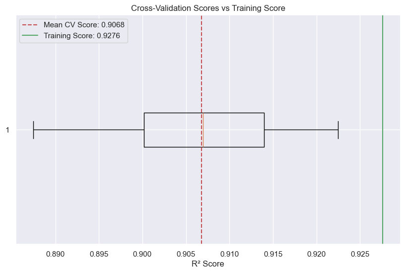

```python
# Boxplot for cross-validation scores
plt.figure(figsize=(10, 6))

plt.boxplot(cv_scores, vert=False)
plt.axvline(mean_cv_score, color='r', linestyle='--', label=f'Mean CV Score: {mean_cv_score:.4f}')
plt.axvline(train_score, color='g', linestyle='-', label=f'Training Score: {train_score:.4f}')

plt.xlabel('R² Score')
plt.title('Cross-Validation Scores vs Training Score')
plt.legend()

plt.show()
```

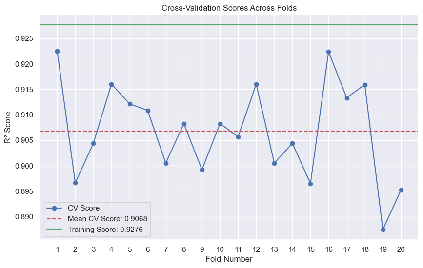

```python
# Line plot for cross-validation scores
folds = np.arange(1, len(cv_scores) + 1)
plt.figure(figsize=(10, 6))
plt.grid(True)

plt.plot(range(1, len(cv_scores) + 1), cv_scores, marker='o', linestyle='-', label='CV Score')
plt.axhline(mean_cv_score, color='r', linestyle='--', label=f'Mean CV Score: {mean_cv_score:.4f}')
plt.axhline(train_score, color='g', linestyle='-', label=f'Training Score: {train_score:.4f}')

plt.title('Cross-Validation Scores Across Folds')
plt.xlabel('Fold Number')
plt.ylabel('R² Score')

plt.xticks(folds)
plt.legend()

plt.show()
```

### Final Evaluation

```python
# Best model from grid search
best_model_rf = grid_search_rf.best_estimator_

# Predict on the test set
y_pred_rf = best_model_rf.predict(X_test)

# Calculate evaluation metrics
accuracy_rf = accuracy_score(y_test, y_pred_rf)
precision_rf = precision_score(y_test, y_pred_rf)
recall_rf = recall_score(y_test, y_pred_rf)
f1_rf = f1_score(y_test, y_pred_rf)

# Display metrics
print(f"Accuracy: {accuracy_rf:.4f}")
print(f"Precision: {precision_rf:.4f}")
print(f"Recall: {recall_rf:.4f}")
print(f"F1 Score: {f1_rf:.4f}")
```

```
Accuracy: 0.9130
Precision: 0.9261
Recall: 0.8999
F1 Score: 0.9128
```

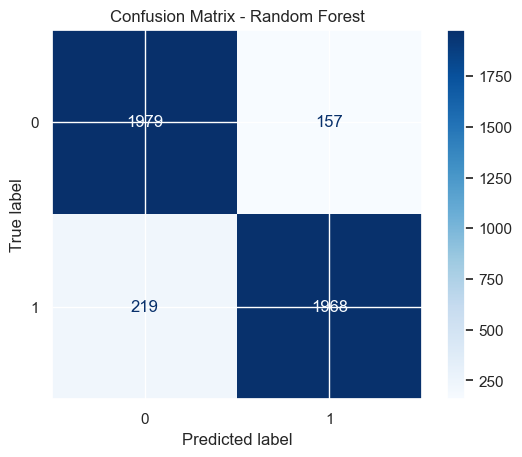

```python
# Generate the confusion matrix
conf_matrix = confusion_matrix(y_test, y_pred_rf)

# Display the confusion matrix
disp = ConfusionMatrixDisplay(confusion_matrix=conf_matrix, display_labels=best_model_rf.classes_)
disp.plot(cmap='Blues')
plt.title('Confusion Matrix - Random Forest')

plt.show()
```

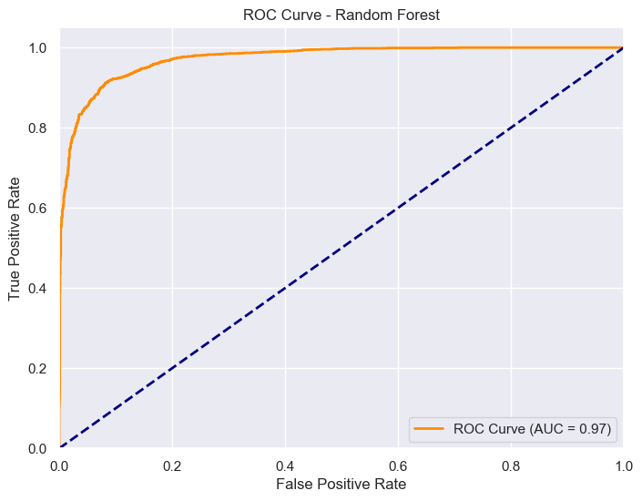

```python
# Get predicted probabilities for the positive class
y_score_rf = best_model_rf.predict_proba(X_test)[:, 1]

# Compute ROC curve and AUC
fpr, tpr, thresholds = roc_curve(y_test, y_score_rf)
roc_auc = auc(fpr, tpr)

# Plot the ROC curve
plt.figure(figsize=(8, 6))

plt.plot(fpr, tpr, color='darkorange', lw=2, label=f'ROC Curve (AUC = {roc_auc:.2f})')
plt.plot([0, 1], [0, 1], color='navy', lw=2, linestyle='--')

plt.title('ROC Curve - Random Forest')
plt.xlim([0.0, 1.0])
plt.ylim([0.0, 1.05])
plt.xlabel('False Positive Rate')
plt.ylabel('True Positive Rate')
plt.legend(loc='lower right')

plt.show()
```

### Notes:

- With a cross-validation mean score of 0.907 and a cross-validation standard deviation of 0.009 the random forest classifier has strong generalisation ability and seems to be performing excellently well with little variance across validation folds. This is indicative of a robust model.
- The training score (0.928) is only 0.02 higher than the cross-validation mean score (0.907). This small gap indicates minimal overfitting and is a sign that the model will perform well with out of sample data.
- Further supporting this is the test set performance metrics where the model has continued to perform well with an accuracy of 91%. It's recall was 90% indicating that it is capable of accurately identifying the expensive homes in the dataset and with a precision of 92% it is able to do so without comprimising on false positive rates. The balance between the precision and recall has also resulted in a strong F1 score.
- Following on from this the area under the ROC (Receiver Operating Characteristic) curve is 97% reflecting the model's discrimination ability.

## KNN Classification

```python
# KNN Classifier Pipeline
full_pipeline_knn = Pipeline([
    ('preprocessing', full_preprocessing),
    ('feature_selection', SelectKBest(score_func=f_classif)),
    ('knn', KNeighborsClassifier())
])

# Hyperparameters to be used in the search
# These are somewhat conservative values as the computational demand increased drastically with a full range
# of possible hyperparameters to search through. It is very likely that a better model could be found provided
# I have more compute.
param_grid_knn = {
    'feature_selection__k': [1, 4, 8, 12, all_features],
    'knn__n_neighbors': [6, 10, 14],
    'knn__weights': ['uniform', 'distance'],
    'knn__metric': ['euclidean', 'manhattan']
}

# Implementing grid search CV
grid_search_knn = GridSearchCV(
    full_pipeline_knn,
    param_grid_knn,
    error_score='raise',  # Just in case for debugging
    cv=5,
    scoring='accuracy',
    n_jobs=-1,
    verbose=3
)

# Fit and output the best hyperparameters with corresponding best score
grid_search_knn.fit(X_train_clean, y_train_clean)
print(f"Best hyperparameters = {grid_search_knn.best_params_}")
print(f"Best score = {grid_search_knn.best_score_}")
```

```
Fitting 5 folds for each of 60 candidates, totalling 300 fits
Best hyperparameters = {'feature_selection__k': 15, 'knn__metric': 'manhattan', 'knn__n_neighbors': 14, 'knn__weights': 'distance'}
Best score = 0.8860674002420653
```

### Analysis of Cross-Validation Scores

```python
# Computing cross-validation scores using the best estimator
# Using more cv folds for greater reliability/accuracy as there is only one model being validated, unlike when searching for the best
# hyperparameters with GridSearchCV. (So I don't have to worry about my CPU melting)
cv_scores = cross_val_score(
    grid_search_knn.best_estimator_,
    X_train_clean,
    y_train_clean,
    cv=20,
    scoring='accuracy'
)

# Cross-validation descriptive statistics
mean_cv_score = np.mean(cv_scores)
std_cv_score = np.std(cv_scores)
min_cv_score = np.min(cv_scores)
max_cv_score = np.max(cv_scores)

# Fit the model on the entire training set and compute training score
best_model = grid_search_knn.best_estimator_
best_model.fit(X_train_clean, y_train_clean)
train_score = r2_score(y_train_clean, best_model.predict(X_train_clean))

print(f"Cross-validation Mean Score: {mean_cv_score:.3f}")
print(f"Cross-validation Standard Deviation: {std_cv_score:.3f}")
print(f"Cross-validation Min Score: {min_cv_score:.3f}")
print(f"Cross-validation Max Score: {max_cv_score:.3f}")
print("")
print(f"Training Score: {train_score:.3f}")

if train_score > mean_cv_score:
    print(f"Training Score is higher than the Cross-validation Mean by {train_score - mean_cv_score:.2f}")
else:
    print(f"Training Score is lower than the Cross-validation Mean by {mean_cv_score - train_score:.2f}")
```

```
Cross-validation Mean Score: 0.888
Cross-validation Standard Deviation: 0.009
Cross-validation Min Score: 0.864
Cross-validation Max Score: 0.900

Training Score: 0.992
Training Score is higher than the Cross-validation Mean by 0.10
```

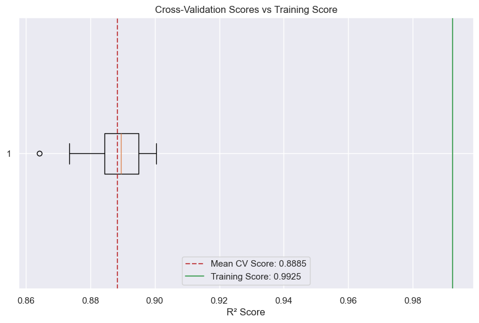

```python
# Boxplot for cross-validation scores
plt.figure(figsize=(10, 6))

plt.boxplot(cv_scores, vert=False)
plt.axvline(mean_cv_score, color='r', linestyle='--', label=f'Mean CV Score: {mean_cv_score:.4f}')
plt.axvline(train_score, color='g', linestyle='-', label=f'Training Score: {train_score:.4f}')

plt.xlabel('R² Score')
plt.title('Cross-Validation Scores vs Training Score')
plt.legend()

plt.show()
```

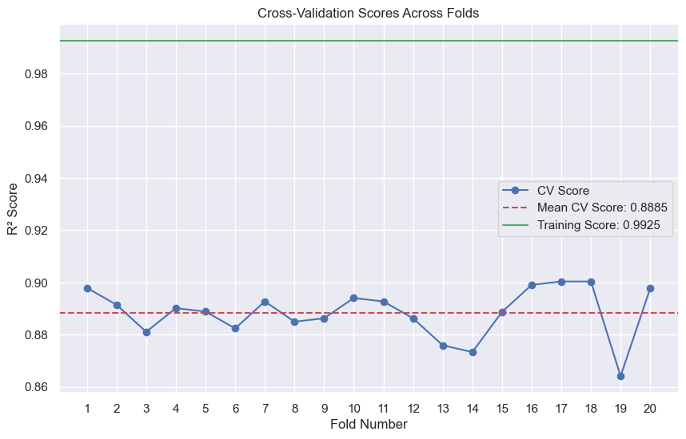

```python
# Line plot for cross-validation scores
folds = np.arange(1, len(cv_scores) + 1)
plt.figure(figsize=(10, 6))
plt.grid(True)

plt.plot(range(1, len(cv_scores) + 1), cv_scores, marker='o', linestyle='-', label='CV Score')
plt.axhline(mean_cv_score, color='r', linestyle='--', label=f'Mean CV Score: {mean_cv_score:.4f}')
plt.axhline(train_score, color='g', linestyle='-', label=f'Training Score: {train_score:.4f}')

plt.title('Cross-Validation Scores Across Folds')
plt.xlabel('Fold Number')
plt.ylabel('R² Score')

plt.xticks(folds)
plt.legend()

plt.show()
```

### Final Evaluation

```python
# Best model from grid search
best_model_knn = grid_search_knn.best_estimator_

# Predict on the test set
y_pred_knn = best_model_knn.predict(X_test)

# Calculate evaluation metrics
accuracy_knn = accuracy_score(y_test, y_pred_knn)
precision_knn = precision_score(y_test, y_pred_knn)
recall_knn = recall_score(y_test, y_pred_knn)
f1_knn = f1_score(y_test, y_pred_knn)

# Display metrics
print(f"Accuracy: {accuracy_knn:.4f}")
print(f"Precision: {precision_knn:.4f}")
print(f"Recall: {recall_knn:.4f}")
print(f"F1 Score: {f1_knn:.4f}")
```

```
Accuracy: 0.8920
Precision: 0.9034
Recall: 0.8807
F1 Score: 0.8919
```

[figure not shown]

```python
# Generate the confusion matrix
conf_matrix = confusion_matrix(y_test, y_pred_knn)

# Display the confusion matrix
disp = ConfusionMatrixDisplay(confusion_matrix=conf_matrix, display_labels=best_model_knn.classes_)
disp.plot(cmap='Blues')
plt.title('Confusion Matrix - Random Forest')

plt.show()
```

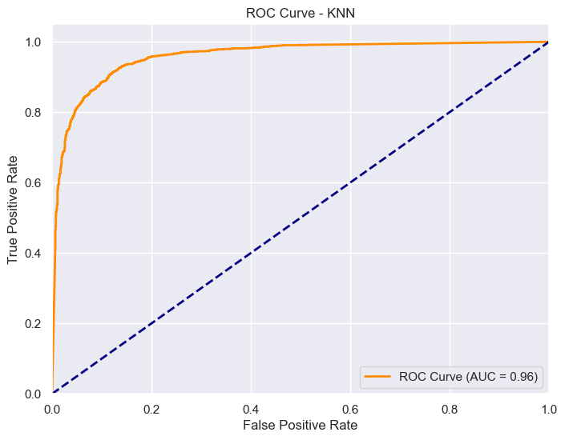

```python
# Get predicted probabilities for the positive class
y_score_knn = best_model_knn.predict_proba(X_test)[:, 1]

# Compute ROC curve and AUC
fpr, tpr, thresholds = roc_curve(y_test, y_score_knn)
roc_auc = auc(fpr, tpr)

# Plot the ROC curve
plt.figure(figsize=(8, 6))

plt.plot(fpr, tpr, color='darkorange', lw=2, label=f'ROC Curve (AUC = {roc_auc:.2f})')
plt.plot([0, 1], [0, 1], color='navy', lw=2, linestyle='--')

plt.xlim([0.0, 1.0])
plt.ylim([0.0, 1.05])
plt.xlabel('False Positive Rate')
plt.ylabel('True Positive Rate')
plt.title('ROC Curve - KNN')
plt.legend(loc='lower right')

plt.show()
```

### Notes:

- The KNN classifier demonstrates strong performance overall, achieving a cross-validation mean score of 0.888, a test accuracy of 0.8920, and an AUC of 0.96. These metrics indicate that the model has excellent discriminatory ability.
- The model achieves a precision of 0.9034 and a recall of 0.8807, indicating that it performs well in both minimizing false positives and capturing true positives. The F1 score of 0.8919, a harmonic mean of precision and recall, highlights that the classifier strikes a good balance between these two metrics.
- The model shows some signs of overfitting, with a large gap of 0.10 between the training score (0.992) and the cross-validation mean score (0.888). This suggests that while the model performs exceptionally well on the training data, it does not generalize perfectly to unseen data. The likely cause of overfitting is the use of distance-based weighting (weights='distance') and a relatively low number of neighbors (n_neighbors=14). These settings may cause the model to memorize local patterns in the training data, leading to high sensitivity to noise and minor variations.
- The confusion matrix reveals relatively low counts of false positives (206) and false negatives (261) compared to the total number of true positives (1926) and true negatives (1930). This results in a false negative rate of ~12%.
- As far as further improvements, currently n_neighbors=14 may be too low, leading to overfitting. Increasing this value to 20–25 could smooth out the decision boundary, making the model less sensitive to noise and improving generalization.

# Footnotes:

- There were warnings raised due to the low variance of some of the input features and the problems this caused with the ANOVA test being used by the f_classif score function in sklearn's SelectKFeatures class (constant features).  
  The solution to this would be to add another preprocessing step that will remove features with low variance (any features with variance below a threshold that I could specify) before applying SelectKFeatures. This could also be added into the pipeline very simply.  
  *warnings:*  
  UserWarning: Features [3 4 5] are constant.warnings.warn("Features %s are constant." % constant_features_idx, UserWarning)  
  RuntimeWarning: invalid value encountered in divide f = msb / msw

```python
!jupyter nbconvert --to html 2464006_concepts_ai_assignment.ipynb
```